# **Practical Machine Learning Project**

## **Background**

Using devices such as Jawbone Up, Nike FuelBand and Fitbit now provides large amount of data about personal activity. One thing that people regularly do is quantify how much of a particular activity they do, but they rarely quantify how well they do it. This project analyzes data from accelerometers on the belt, forearm, arm and dumbell of 6 participants, who performed barbell lifts correctly and incorrectly in 5 different ways. The goal of this project is to predict the manner in which they did the exercise, which is the “classe” variable in the training set. Predication can be made with any of other variables. Once the prediction model is built, it will be used to predict 20 different test cases. More information is available at http://groupware.les.inf.puc-rio.br/har. The training data are available at https://d396qusza40orc.cloudfront.net/predmachlearn/pml-training.csv and the test data are available at https://d396qusza40orc.cloudfront.net/predmachlearn/pml-testing.csv.

## **Data Loading and Partitioning**

```r
library(caret)
require(rpart)
library(rattle)
require(randomForest)
# Read training data and the data of test cases
trainraw <- read.csv("pml-training.csv")
testing <- read.csv("pml-testing.csv")

# Set seed for reproducibility
set.seed(57)

# Shuffle the training data to randomize the order of observations
trainrawsf <- trainraw[sample(nrow(trainraw)),]

# Create training and testing sets
intrain <- createDataPartition(y=trainrawsf$classe, p = 0.7, list = FALSE)
training <- trainrawsf[intrain, ]
validtest <- trainrawsf[-intrain, ]
```

```r
# Show the number of observations for each dataset
dim(trainraw)
```

```
## [1] 19622   160
```

```r
dim(training)
```

```
## [1] 13737   160
```

```r
dim(validtest)
```

```
## [1] 5885  160
```

The original training set has 160 features and 19622 observations. The newly created training and testing sets has 13737 and 5885 observations respectively.

## **Data Preprocessing**

### **Remove useless features**

```r
# Discard useless features ("X", user_name" and "cvtd_timestamp")
trainrm <- training[ , -c(1, 2, 5)]

# Discard features that are almost entirly NA
trainnona<-trainrm[, (colSums(is.na(trainrm)) < nrow(trainrm)/2)]

# Dimension of current training set
dim(trainnona)
```

```
## [1] 13737    90
```

After removing the useless features and the mostly NA features, the processed training set now has 90 features.

### **Extract useful features**

```r
# Discard zero- and near zero-variance features
trainnzv <- nearZeroVar(trainnona)
length(trainnzv)
```

```
## [1] 34
```

```r
trainnzvfilt <- trainnona[, -trainnzv]
dim(trainnzvfilt)
```

```
## [1] 13737    56
```

```r
# Convert "classe" into numeric because cor() can only take numeric dada.frame
trainnzvfilt$classe <- factor(trainnzvfilt$classe, labels = c(1:5))
trainnzvfilt$classe <- as.numeric(trainnzvfilt$classe)

# Identify and remove correlated features
traincor <- cor(trainnzvfilt, use ="complete.obs")
trainhicor <- findCorrelation(traincor, cutoff = .75)
trainfiltered <- trainnzvfilt[,-trainhicor]
dim(trainfiltered)
```

```
## [1] 13737    37
```

```r
# Change "classe" from numeric variable back to factor variable
trainfiltered$classe <- factor(trainfiltered$classe, labels = c("A", "B", "C", "D", "E"))
```

After removing zero- and near zero-variance features, the training set has 56 features. After discarding the closely correlated features, the new training set now has 37 features remained.

## **Fit Models**

### **Set cross validation method**

```r
fitcontrol<-trainControl(method = "cv", number = 5)
```

K-fold is used as cross validation method with K = 5.

### **Model 1 - classification tree**

```r
# Fit the training set with classification tree model
modelfitct <- train(classe ~ ., data = trainfiltered, trControl = fitcontrol, method="rpart")
```

```r
# Show the detailed information of classification tree model
print(modelfitct, digits=3)
```

```
## CART
##
## 13737 samples
##    36 predictor
##     5 classes: 'A', 'B', 'C', 'D', 'E'
##
## No pre-processing
## Resampling: Cross-Validated (5 fold)
## Summary of sample sizes: 10989, 10989, 10991, 10988, 10991
## Resampling results across tuning parameters:
##
##   cp      Accuracy  Kappa  Accuracy SD  Kappa SD
##   0.0405  0.378     0.152  0.129        0.208
##   0.0504  0.358     0.124  0.100        0.170
##   0.0677  0.358     0.124  0.100        0.170
##
## Accuracy was used to select the optimal model using  the largest value.
## The final value used for the model was cp = 0.0405.
```

```r
print(modelfitct$finalModel, digits=3)
```

```
## n= 13737
##
## node), split, n, loss, yval, (yprob)
##       * denotes terminal node
##
##  1) root 13737 9830 A (0.28 0.19 0.17 0.16 0.18)
##    2) pitch_forearm< -33.7 1121    7 A (0.99 0.0062 0 0 0) *
##    3) pitch_forearm>=-33.7 12616 9820 A (0.22 0.21 0.19 0.18 0.2)
##      6) magnet_belt_z>=-384 9760 7490 A (0.23 0.23 0.21 0.2 0.12)
##       12) roll_dumbbell< 67.5 7109 5020 A (0.29 0.17 0.28 0.16 0.099)
##         24) roll_forearm< 124 4764 2750 A (0.42 0.18 0.19 0.13 0.079) *
##         25) roll_forearm>=124 2345 1280 C (0.029 0.15 0.45 0.23 0.14) *
##       13) roll_dumbbell>=67.5 2651 1620 B (0.071 0.39 0.038 0.32 0.18)
##         26) total_accel_dumbbell>=6.5 1699  783 B (0.026 0.54 0.058 0.14 0.24) *
##         27) total_accel_dumbbell< 6.5 952  339 D (0.15 0.12 0.0021 0.64 0.079) *
##      7) magnet_belt_z< -384 2856 1520 E (0.18 0.14 0.12 0.09 0.47) *
```

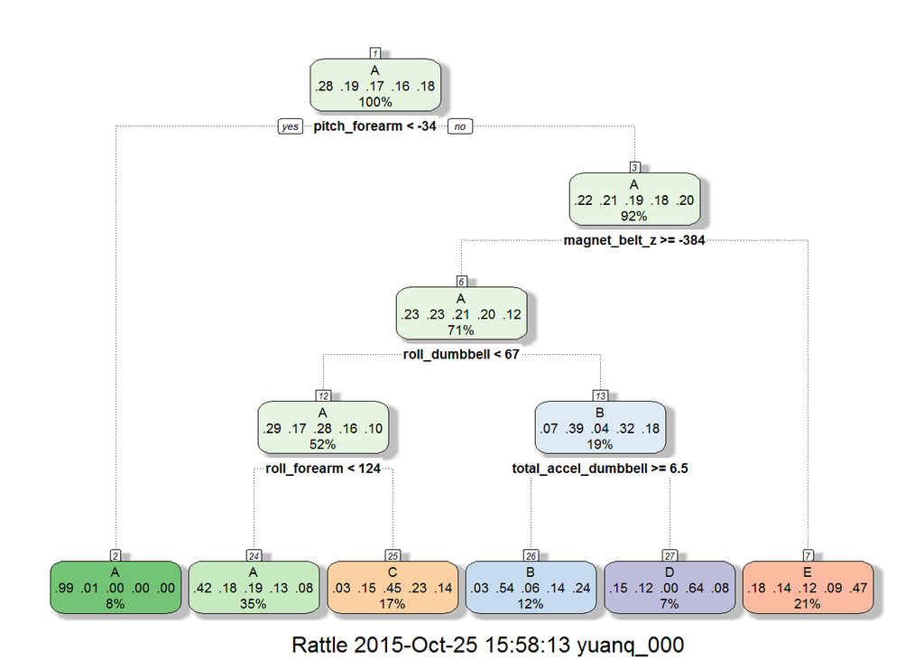

```r
# Demonstrate the algorithm of classification tree model
fancyRpartPlot(modelfitct$finalModel)
```

### **Model 2 - random forest**

```r
# Fit the training set with random forest model
modelfitrf<-train(classe ~ ., data = trainfiltered, trControl = fitcontrol, method="rf", importance = T)
```

```r
# Show the detailed information of random forest model
print(modelfitrf, digits=3)
```

```
## Random Forest
##
## 13737 samples
##    36 predictor
##     5 classes: 'A', 'B', 'C', 'D', 'E'
##
## No pre-processing
## Resampling: Cross-Validated (5 fold)
## Summary of sample sizes: 10989, 10991, 10988, 10990, 10990
## Resampling results across tuning parameters:
##
##   mtry  Accuracy  Kappa  Accuracy SD  Kappa SD
##    2    0.996     0.994  0.000399     0.000504
##   19    0.999     0.999  0.000305     0.000385
##   36    0.997     0.996  0.000914     0.001157
##
## Accuracy was used to select the optimal model using  the largest value.
## The final value used for the model was mtry = 19.
```

```r
print(modelfitrf$finalModel, digits=3)
```

```
##
## Call:
##  randomForest(x = x, y = y, mtry = param$mtry, importance = ..1)
##                Type of random forest: classification
##                      Number of trees: 500
## No. of variables tried at each split: 19
##
##         OOB estimate of  error rate: 0.1%
## Confusion matrix:
##      A    B    C    D    E class.error
## A 3906    0    0    0    0 0.000000000
## B    3 2654    0    0    1 0.001504891
## C    0    3 2390    3    0 0.002504174
## D    0    0    2 2248    2 0.001776199
## E    0    0    0    0 2525 0.000000000
```

```r
# Calculate variable importance of random forest model
virf <- varImp(modelfitrf)
virf
```

```
## rf variable importance
##
##   variables are sorted by maximum importance across the classes
##   only 20 most important variables shown (out of 36)
##
##                           A     B      C      D      E
## raw_timestamp_part_1 75.608 87.78 92.966 100.00 71.783
## magnet_belt_z        33.270 47.02 41.003  60.93 52.186
## num_window           31.221 53.31 53.637  39.42 41.402
## yaw_belt             32.367 41.07 42.070  52.18 37.150
## roll_dumbbell        24.918 29.62 48.524  32.92 27.265
## pitch_forearm        26.798 39.01 43.259  36.76 40.887
## roll_forearm         26.757 23.40 31.159  19.11 23.417
## total_accel_dumbbell 17.538 26.30 20.696  26.21 24.033
## yaw_dumbbell         20.090 25.61 26.135  25.39 21.802
## magnet_belt_x         7.857 16.40 13.134  13.81 22.463
## gyros_belt_z         13.740 21.40 14.140  17.48 18.600
## pitch_dumbbell        9.704 18.94 12.384  11.17 11.460
## accel_forearm_z      11.237 12.19 11.904  18.03 14.954
## roll_arm              9.367 16.41 13.430  17.76 14.739
## accel_forearm_x       8.466 15.90 12.669  14.69 17.511
## gyros_arm_y           8.220 12.20 16.713  13.58  9.378
## pitch_arm             8.436 12.86  8.840  14.14 10.447
## magnet_forearm_z     13.483 13.09 10.953  12.99 12.029
## gyros_dumbbell_y     10.296 10.10 11.777  12.86  9.192
## yaw_arm               7.459 11.37  6.863  12.82  8.991
```

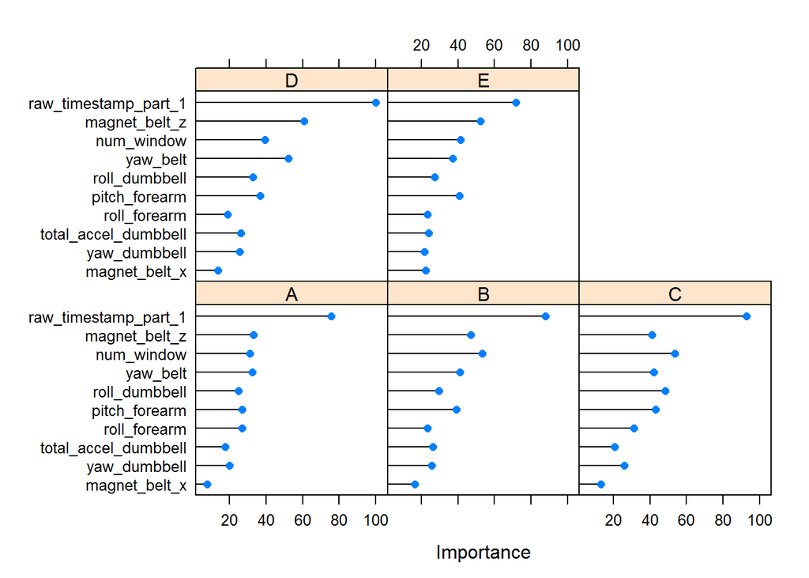

```r
# Demonstrate variable importance of random forest model
plot(virf,10)
```

## **Evaluate Models**

### **Predict with validtest dataset**

```r
# Predict with validtest dataset using classification tree model
predictct<-predict(modelfitct, validtest)

# Predict with validtest dataset using random forest model
predictrf<-predict(modelfitrf, validtest)
```

### **Calculate accuracy of predication**

```r
# Calculate predication accuracy of classification tree model
confusionMatrix(predictct, validtest$classe)
```

```
## Confusion Matrix and Statistics
##
##           Reference
## Prediction    A    B    C    D    E
##          A 1322  347  402  283  172
##          B   22  414   45   94  176
##          C   39  140  427  234  140
##          D   65   42    0  249   33
##          E  226  196  152  104  561
##
## Overall Statistics
##
##                Accuracy : 0.5052
##                  95% CI : (0.4923, 0.518)
##     No Information Rate : 0.2845
##     P-Value [Acc > NIR] : < 2.2e-16
##
##                   Kappa : 0.3612
##  Mcnemar's Test P-Value : < 2.2e-16
##
## Statistics by Class:
##
##                      Class: A Class: B Class: C Class: D Class: E
## Sensitivity            0.7897  0.36348  0.41618  0.25830  0.51848
## Specificity            0.7141  0.92899  0.88619  0.97155  0.85884
## Pos Pred Value         0.5234  0.55126  0.43571  0.64010  0.45278
## Neg Pred Value         0.8952  0.85878  0.87788  0.86991  0.88786
## Prevalence             0.2845  0.19354  0.17434  0.16381  0.18386
## Detection Rate         0.2246  0.07035  0.07256  0.04231  0.09533
## Detection Prevalence   0.4292  0.12761  0.16653  0.06610  0.21054
## Balanced Accuracy      0.7519  0.64623  0.65118  0.61492  0.68866
```

```r
# Calculate predication accuracy of random forest model
confusionMatrix(predictrf, validtest$classe)
```

```
## Confusion Matrix and Statistics
##
##           Reference
## Prediction    A    B    C    D    E
##          A 1674    5    0    0    0
##          B    0 1133    2    0    0
##          C    0    0 1024    0    0
##          D    0    0    0  964    0
##          E    0    1    0    0 1082
##
## Overall Statistics
##
##                Accuracy : 0.9986
##                  95% CI : (0.9973, 0.9994)
##     No Information Rate : 0.2845
##     P-Value [Acc > NIR] : < 2.2e-16
##
##                   Kappa : 0.9983
##  Mcnemar's Test P-Value : NA
##
## Statistics by Class:
##
##                      Class: A Class: B Class: C Class: D Class: E
## Sensitivity            1.0000   0.9947   0.9981   1.0000   1.0000
## Specificity            0.9988   0.9996   1.0000   1.0000   0.9998
## Pos Pred Value         0.9970   0.9982   1.0000   1.0000   0.9991
## Neg Pred Value         1.0000   0.9987   0.9996   1.0000   1.0000
## Prevalence             0.2845   0.1935   0.1743   0.1638   0.1839
## Detection Rate         0.2845   0.1925   0.1740   0.1638   0.1839
## Detection Prevalence   0.2853   0.1929   0.1740   0.1638   0.1840
## Balanced Accuracy      0.9994   0.9972   0.9990   1.0000   0.9999
```

The prediction accuracy of classification tree model is 50.52% and the prediction accuracy of random forest method is 99.86%. Due to the high accuracy, random forest model is selected for predicting the test cases.

## **Prediction Results**

```r
classoftestdataset<-predict(modelfitrf, testing)
classoftestdataset
```

```
##  [1] B A B A A E D B A A B C B A E E A B B B
## Levels: A B C D E
```

### **Calculate in sample error**

In sample error = (1 - accuracy) x 100. For random forest model, the accuracy is 99.90%, therefore its in sample error is (1 - 0.9990) x 100 = 0.10%.

### **Estimate out of sample error**

```r
# Length of the predictions in validtest set using random forest method
length(predictrf)
```

```
## [1] 5885
```

```r
# Calculate the true prediction accuracy
outofsampleaccuracy <- sum(predictrf == validtest$classe)/length(predictrf)
outofsampleaccuracy
```

```
## [1] 0.9986406
```

```r
# out of sample error
outofsampleerror <- 1 - outofsampleaccuracy
round(outofsampleerror * 100, 2)
```

```
## [1] 0.14
```

The estimated out of sample error of random forest model is 0.14%. The random forest model built in this project shows a slightly worse out of sample error than the in sample error, indicating there is no overfitting.

## **References**

Velloso, E.; Bulling, A.; Gellersen, H.; Ugulino, W.; Fuks, H. Qualitative Activity Recognition of Weight Lifting Exercises. Proceedings of 4th International Conference in Cooperation with SIGCHI (Augmented Human ’13) . Stuttgart, Germany: ACM SIGCHI, 2013.